# Parkinson’s Disease RNA-Seq analysis

Gabriel Ramirez-Vilchis

2025-02-07

# 1 Introduction

Parkinson’s disease (PD) is a neurodegenerative disorder. It consists of neuronal loss in the substantia nigra, which causes striatal dopamine deficiency. Important hallmarks of PD are aggregates of α-synuclein (α-syn). In this project, RNA-seq data from mice with induced α-syn accumulation is analyzed in order to learn more about microglia role in PD (Poewe et al. 2017).

# 2 Antecedents and data source

It is known that activated microglia is usually present in PD and it can promote α-syn aggregation. Nevertheless, it is not yet completely understood how microglia participates in α-syn cell-to-cell transfer.

I analyzed data generated during the research previously mentioned. The data is available at https://www.ncbi.nlm.nih.gov/geo/query/acc.cgi?acc=GSE130683.

# 3 Hypothesis

Stimulation of microglia affects α-syn transfer between neuronal cells.

# 4 Objective

To analyze RNA-seq data from mice with induced α-syn accumulation in order to determine the effect of microglia stimulation on α-syn transfer between cells.

# 5 Data processing

## 5.1 Library importation

First, the libraries needed for the analysis are imported. They include libraries for data manipulation, normalization, and visualization.

```r
# Import libraries
library(recount3)
library(SummarizedExperiment)
library(edgeR)
library(ggplot2)
library(limma)
library(pheatmap)
library(RColorBrewer)
```

## 5.2 Data selection

The data is selected from the available projects in *recount3*. The project selected is SRP194918, which contains data from mice with induced α-syn accumulation.

```r
# List all available projects for mouse
mouse_projects <- available_projects(organism = "mouse")
```

```
## 2025-02-07 22:27:47.837752 caching file sra.recount_project.MD.gz.
```

```r
# Extract the project information
proj_info <- subset(
  mouse_projects,
  project == "SRP194918" & project_type == "data_sources"
)

# Create a recount object for the SRP058181 project
rse_gene_SRP194918 <- create_rse(proj_info)
```

```
## 2025-02-07 22:27:51.966258 downloading and reading the metadata.
```

```
## 2025-02-07 22:27:52.57307 caching file sra.sra.SRP194918.MD.gz.
```

```
## 2025-02-07 22:27:53.205212 caching file sra.recount_project.SRP194918.MD.gz.
```

```
## 2025-02-07 22:27:53.920731 caching file sra.recount_qc.SRP194918.MD.gz.
```

```
## 2025-02-07 22:27:54.629545 caching file sra.recount_seq_qc.SRP194918.MD.gz.
```

```
## 2025-02-07 22:27:55.377235 caching file sra.recount_pred.SRP194918.MD.gz.
```

```
## 2025-02-07 22:27:55.59794 downloading and reading the feature information.
```

```
## 2025-02-07 22:27:56.246265 caching file mouse.gene_sums.M023.gtf.gz.
```

```
## 2025-02-07 22:27:56.728348 downloading and reading the counts: 17 samples across 55421 features.
```

```
## 2025-02-07 22:27:57.258379 caching file sra.gene_sums.SRP194918.M023.gz.
```

```
## 2025-02-07 22:27:57.570603 constructing the RangedSummarizedExperiment (rse) object.
```

```r
rse_gene_SRP194918
```

```
## class: RangedSummarizedExperiment
## dim: 55421 17
## metadata(8): time_created recount3_version ... annotation recount3_url
## assays(1): raw_counts
## rownames(55421): ENSMUSG00000079800.2 ENSMUSG00000095092.1 ...
##   ENSMUSG00000096850.1 ENSMUSG00000099871.1
## rowData names(11): source type ... havana_gene tag
## colnames(17): SRR9007214 SRR9007215 ... SRR9007216 SRR9007217
## colData names(177): rail_id external_id ...
##   recount_pred.curated.cell_line BigWigURL
```

```r
# Analyze the project
rowData(rse_gene_SRP194918)
```

```
## DataFrame with 55421 rows and 11 columns
##                        source     type bp_length     phase              gene_id
##                      <factor> <factor> <numeric> <integer>          <character>
## ENSMUSG00000079800.2  ENSEMBL     gene      1271        NA ENSMUSG00000079800.2
## ENSMUSG00000095092.1  ENSEMBL     gene       366        NA ENSMUSG00000095092.1
## ENSMUSG00000079192.2  ENSEMBL     gene       255        NA ENSMUSG00000079192.2
## ENSMUSG00000079794.2  ENSEMBL     gene       255        NA ENSMUSG00000079794.2
## ENSMUSG00000094799.1  ENSEMBL     gene       366        NA ENSMUSG00000094799.1
## ...                       ...      ...       ...       ...                  ...
## ENSMUSG00000095366.2  HAVANA      gene      1181        NA ENSMUSG00000095366.2
## ENSMUSG00000095134.2  HAVANA      gene      1248        NA ENSMUSG00000095134.2
## ENSMUSG00000096768.8  HAVANA      gene      4501        NA ENSMUSG00000096768.8
## ENSMUSG00000096850.1  ENSEMBL     gene       309        NA ENSMUSG00000096850.1
## ENSMUSG00000099871.1  HAVANA      gene       548        NA ENSMUSG00000099871.1
##                                   gene_type   gene_name       level      mgi_id
##                                 <character> <character> <character> <character>
## ENSMUSG00000079800.2         protein_coding  AC125149.3           3          NA
## ENSMUSG00000095092.1         protein_coding  AC125149.5           3          NA
## ENSMUSG00000079192.2         protein_coding  AC125149.1           3          NA
## ENSMUSG00000079794.2         protein_coding  AC125149.2           3          NA
## ENSMUSG00000094799.1         protein_coding  AC125149.4           3          NA
## ...                                     ...         ...         ...         ...
## ENSMUSG00000095366.2                 lncRNA     Gm21860           2 MGI:5434024
## ENSMUSG00000095134.2 unprocessed_pseudogene    Mid1-ps1           2 MGI:5780070
## ENSMUSG00000096768.8                 lncRNA     Gm47283           2 MGI:6096131
## ENSMUSG00000096850.1         protein_coding     Gm21748           3 MGI:5433912
## ENSMUSG00000099871.1 unprocessed_pseudogene     Gm21742           2 MGI:5433906
##                               havana_gene         tag
##                               <character> <character>
## ENSMUSG00000079800.2                   NA          NA
## ENSMUSG00000095092.1                   NA          NA
## ENSMUSG00000079192.2                   NA          NA
## ENSMUSG00000079794.2                   NA          NA
## ENSMUSG00000094799.1                   NA          NA
## ...                                   ...         ...
## ENSMUSG00000095366.2 OTTMUSG00000074801.1          NA
## ENSMUSG00000095134.2 OTTMUSG00000047373.1          NA
## ENSMUSG00000096768.8 OTTMUSG00000074820.2          NA
## ENSMUSG00000096850.1                   NA          NA
## ENSMUSG00000099871.1 OTTMUSG00000047374.1          NA
```

```r
rowRanges(rse_gene_SRP194918)
```

```
## GRanges object with 55421 ranges and 11 metadata columns:
##                          seqnames            ranges strand |   source     type
##                             <Rle>         <IRanges>  <Rle> | <factor> <factor>
##   ENSMUSG00000079800.2 GL456210.1        9124-58882      - |  ENSEMBL     gene
##   ENSMUSG00000095092.1 GL456210.1     108390-110303      - |  ENSEMBL     gene
##   ENSMUSG00000079192.2 GL456210.1     123792-124928      + |  ENSEMBL     gene
##   ENSMUSG00000079794.2 GL456210.1     135395-136519      - |  ENSEMBL     gene
##   ENSMUSG00000094799.1 GL456210.1     147792-149707      + |  ENSEMBL     gene
##                    ...        ...               ...    ... .      ...      ...
##   ENSMUSG00000095366.2       chrY 90752427-90755467      - |  HAVANA      gene
##   ENSMUSG00000095134.2       chrY 90753057-90763485      + |  HAVANA      gene
##   ENSMUSG00000096768.8       chrY 90784738-90816465      + |  HAVANA      gene
##   ENSMUSG00000096850.1       chrY 90838869-90839177      - |  ENSEMBL     gene
##   ENSMUSG00000099871.1       chrY 90837413-90844040      + |  HAVANA      gene
##                        bp_length     phase              gene_id
##                        <numeric> <integer>          <character>
##   ENSMUSG00000079800.2      1271      <NA> ENSMUSG00000079800.2
##   ENSMUSG00000095092.1       366      <NA> ENSMUSG00000095092.1
##   ENSMUSG00000079192.2       255      <NA> ENSMUSG00000079192.2
##   ENSMUSG00000079794.2       255      <NA> ENSMUSG00000079794.2
##   ENSMUSG00000094799.1       366      <NA> ENSMUSG00000094799.1
##                    ...       ...       ...                  ...
##   ENSMUSG00000095366.2      1181      <NA> ENSMUSG00000095366.2
##   ENSMUSG00000095134.2      1248      <NA> ENSMUSG00000095134.2
##   ENSMUSG00000096768.8      4501      <NA> ENSMUSG00000096768.8
##   ENSMUSG00000096850.1       309      <NA> ENSMUSG00000096850.1
##   ENSMUSG00000099871.1       548      <NA> ENSMUSG00000099871.1
##                                     gene_type   gene_name       level
##                                   <character> <character> <character>
##   ENSMUSG00000079800.2         protein_coding  AC125149.3           3
##   ENSMUSG00000095092.1         protein_coding  AC125149.5           3
##   ENSMUSG00000079192.2         protein_coding  AC125149.1           3
##   ENSMUSG00000079794.2         protein_coding  AC125149.2           3
##   ENSMUSG00000094799.1         protein_coding  AC125149.4           3
##                    ...                    ...         ...         ...
##   ENSMUSG00000095366.2                 lncRNA     Gm21860           2
##   ENSMUSG00000095134.2 unprocessed_pseudogene    Mid1-ps1           2
##   ENSMUSG00000096768.8                 lncRNA     Gm47283           2
##   ENSMUSG00000096850.1         protein_coding     Gm21748           3
##   ENSMUSG00000099871.1 unprocessed_pseudogene     Gm21742           2
##                             mgi_id          havana_gene         tag
##                        <character>          <character> <character>
##   ENSMUSG00000079800.2        <NA>                 <NA>        <NA>
##   ENSMUSG00000095092.1        <NA>                 <NA>        <NA>
##   ENSMUSG00000079192.2        <NA>                 <NA>        <NA>
##   ENSMUSG00000079794.2        <NA>                 <NA>        <NA>
##   ENSMUSG00000094799.1        <NA>                 <NA>        <NA>
##                    ...         ...                  ...         ...
##   ENSMUSG00000095366.2 MGI:5434024 OTTMUSG00000074801.1        <NA>
##   ENSMUSG00000095134.2 MGI:5780070 OTTMUSG00000047373.1        <NA>
##   ENSMUSG00000096768.8 MGI:6096131 OTTMUSG00000074820.2        <NA>
##   ENSMUSG00000096850.1 MGI:5433912                 <NA>        <NA>
##   ENSMUSG00000099871.1 MGI:5433906 OTTMUSG00000047374.1        <NA>
##   -------
##   seqinfo: 45 sequences from an unspecified genome; no seqlengths
```

## 5.3 Data formatting

The data is transformed to read counts and important data for analysis is added. The data types are converted to factors and the data is summarized.

```r
# Transform nucleotide counts to read counts
assay(rse_gene_SRP194918, "counts") <- compute_read_counts(rse_gene_SRP194918)

# Add important data for analysis
rse_gene_SRP194918 <- expand_sra_attributes(rse_gene_SRP194918)

# Check the data format
rse_gene_SRP194918$sra.sample_attributes[1:3]
```

```
## [1] "age;;10-14 weeks old|injected with;;PBS|source_name;;brain-striatum|strain;;C57BL/6J|tissue;;ipsilateral striatum|treatment;;AAV over expression, neural graft, inflammatory injection"
## [2] "age;;10-14 weeks old|injected with;;PBS|source_name;;brain-striatum|strain;;C57BL/6J|tissue;;ipsilateral striatum|treatment;;AAV over expression, neural graft, inflammatory injection"
## [3] "age;;10-14 weeks old|injected with;;LPS|source_name;;brain-striatum|strain;;C57BL/6J|tissue;;ipsilateral striatum|treatment;;AAV over expression, neural graft, inflammatory injection"
```

```r
# Review data of interest
colData(rse_gene_SRP194918)[
  ,
  grepl("^sra_attribute", colnames(colData(rse_gene_SRP194918)))
]
```

```
## DataFrame with 17 rows and 6 columns
##            sra_attribute.age sra_attribute.injected_with
##                  <character>                 <character>
## SRR9007214   10-14 weeks old                         PBS
## SRR9007215   10-14 weeks old                         PBS
## SRR9007218   10-14 weeks old                         LPS
## SRR9007219   10-14 weeks old                         LPS
## SRR9007220   10-14 weeks old                         LPS
## ...                      ...                         ...
## SRR9007228   10-14 weeks old                         IL4
## SRR9007229   10-14 weeks old                         IL4
## SRR9007230   10-14 weeks old                         IL4
## SRR9007216   10-14 weeks old                         PBS
## SRR9007217   10-14 weeks old                         PBS
##            sra_attribute.source_name sra_attribute.strain sra_attribute.tissue
##                          <character>          <character>          <character>
## SRR9007214            brain-striatum             C57BL/6J ipsilateral striatum
## SRR9007215            brain-striatum             C57BL/6J ipsilateral striatum
## SRR9007218            brain-striatum             C57BL/6J ipsilateral striatum
## SRR9007219            brain-striatum             C57BL/6J ipsilateral striatum
## SRR9007220            brain-striatum             C57BL/6J ipsilateral striatum
## ...                              ...                  ...                  ...
## SRR9007228            brain-striatum             C57BL/6J ipsilateral striatum
## SRR9007229            brain-striatum             C57BL/6J ipsilateral striatum
## SRR9007230            brain-striatum             C57BL/6J ipsilateral striatum
## SRR9007216            brain-striatum             C57BL/6J ipsilateral striatum
## SRR9007217            brain-striatum             C57BL/6J ipsilateral striatum
##            sra_attribute.treatment
##                        <character>
## SRR9007214  AAV over expression,..
## SRR9007215  AAV over expression,..
## SRR9007218  AAV over expression,..
## SRR9007219  AAV over expression,..
## SRR9007220  AAV over expression,..
## ...                            ...
## SRR9007228  AAV over expression,..
## SRR9007229  AAV over expression,..
## SRR9007230  AAV over expression,..
## SRR9007216  AAV over expression,..
## SRR9007217  AAV over expression,..
```

```r
# Convert data types to factors
rse_gene_SRP194918$sra_attribute.age <-
  factor(rse_gene_SRP194918$sra_attribute.age)
rse_gene_SRP194918$sra_attribute.injected_with <-
  factor(rse_gene_SRP194918$sra_attribute.injected_with)
rse_gene_SRP194918$sra_attribute.source_name <-
  factor(rse_gene_SRP194918$sra_attribute.source_name)
rse_gene_SRP194918$sra_attribute.strain <-
  factor(rse_gene_SRP194918$sra_attribute.strain)
rse_gene_SRP194918$sra_attribute.tissue <-
  factor(rse_gene_SRP194918$sra_attribute.tissue)
rse_gene_SRP194918$sra_attribute.treatment <-
  factor(rse_gene_SRP194918$sra_attribute.treatment)

# Summarize data
summary(as.data.frame(colData(rse_gene_SRP194918)[
  ,
  grepl("^sra_attribute", colnames(colData(rse_gene_SRP194918)))
]))
```

```
##        sra_attribute.age sra_attribute.injected_with  sra_attribute.source_name
##  10-14 weeks old:17      IL4:8                       brain-striatum:17
##                          LPS:5
##                          PBS:4
##  sra_attribute.strain           sra_attribute.tissue
##  C57BL/6J:17          ipsilateral striatum:17
##
##
##                                               sra_attribute.treatment
##  AAV over expression, neural graft, inflammatory injection:17
##
##
```

There are 17 samples. While the only relevant difference is the injection, I analyzed the effects that it has in gene expression.

## 5.4 Data filtering

The data is filtered to remove genes with low expression.

```r
# Check quality of the data
rse_gene_SRP194918$assigned_gene_prop <-
  rse_gene_SRP194918$recount_qc.gene_fc_count_all.assigned /
  rse_gene_SRP194918$recount_qc.gene_fc_count_all.total
summary(rse_gene_SRP194918$assigned_gene_prop)
```

```
##    Min. 1st Qu.  Median    Mean 3rd Qu.    Max.
##  0.6815  0.6975  0.7143  0.7105  0.7232  0.7448
```

```r
# Observe differences among samples injected with different substances
with(colData(rse_gene_SRP194918),
     tapply(assigned_gene_prop,
            sra_attribute.injected_with,
            summary))
```

```
## $IL4
##    Min. 1st Qu.  Median    Mean 3rd Qu.    Max.
##  0.6975  0.7089  0.7163  0.7147  0.7231  0.7241
##
## $LPS
##    Min. 1st Qu.  Median    Mean 3rd Qu.    Max.
##  0.6815  0.6839  0.6878  0.7025  0.7143  0.7448
##
## $PBS
##    Min. 1st Qu.  Median    Mean 3rd Qu.    Max.
##  0.6862  0.6974  0.7133  0.7122  0.7282  0.7360
```

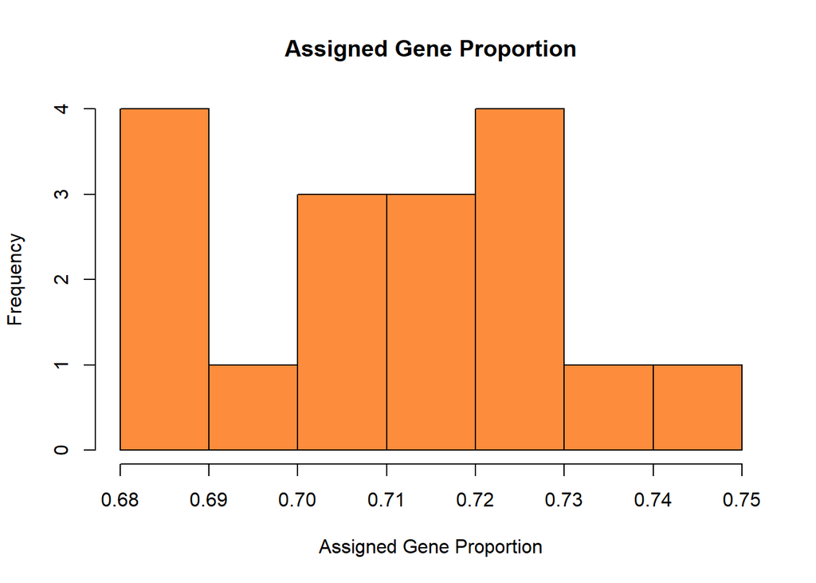

```r
# Plot the distribution of the assigned gene proportion
hist(rse_gene_SRP194918$assigned_gene_prop,
     col = "#fd8d3c",
     main = "Assigned Gene Proportion",
     xlab = "Assigned Gene Proportion")
```

```r
# Save the unfiltered data
rse_gene_SRP194918_unfiltered <- rse_gene_SRP194918

# Filter genes with low expression
rse_gene_SRP194918 <-
  rse_gene_SRP194918[edgeR::filterByExpr(rse_gene_SRP194918),]
```

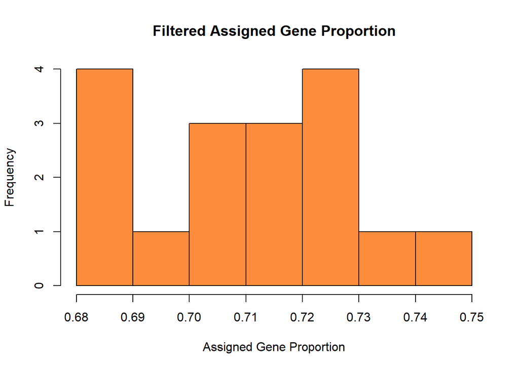

```r
# Plot the distribution of the assigned gene proportion after filtering
hist(rse_gene_SRP194918$assigned_gene_prop,
     col = "#fd8d3c",
     main = "Filtered Assigned Gene Proportion",
     xlab = "Assigned Gene Proportion")
```

```r
# Check the expression of genes that were not filtered out
gene_means <- rowMeans(assay(rse_gene_SRP194918, "counts"))
summary(gene_means)
```

```
##      Min.   1st Qu.    Median      Mean   3rd Qu.      Max.
##      12.5      93.4     507.2    2083.3    1720.7 1701927.8
```

```r
# Check the percentage of genes that were not filtered out
round(nrow(rse_gene_SRP194918) / nrow(rse_gene_SRP194918_unfiltered) * 100, 2)
```

```
## [1] 39.88
```

## 5.5 Data normalization

The data is normalized using Log-fold changes.

```r
# Create the list for normalization
dge <- DGEList(counts = assay(rse_gene_SRP194918, "counts"),
               genes = rowData(rse_gene_SRP194918))

# Calculate the normalization factors
dge <- calcNormFactors(dge)
```

# 6 Differential expression analysis

The differential expression analysis is performed using the *limma* package.

Model matrix was created according to the injection group and the assigned gene proportion.

Most differentially expressed genes were calculated using the Bayes method and were identified in a Volcano plot. Also a heatmap was created with the 50 top genes to analyze differential expression.

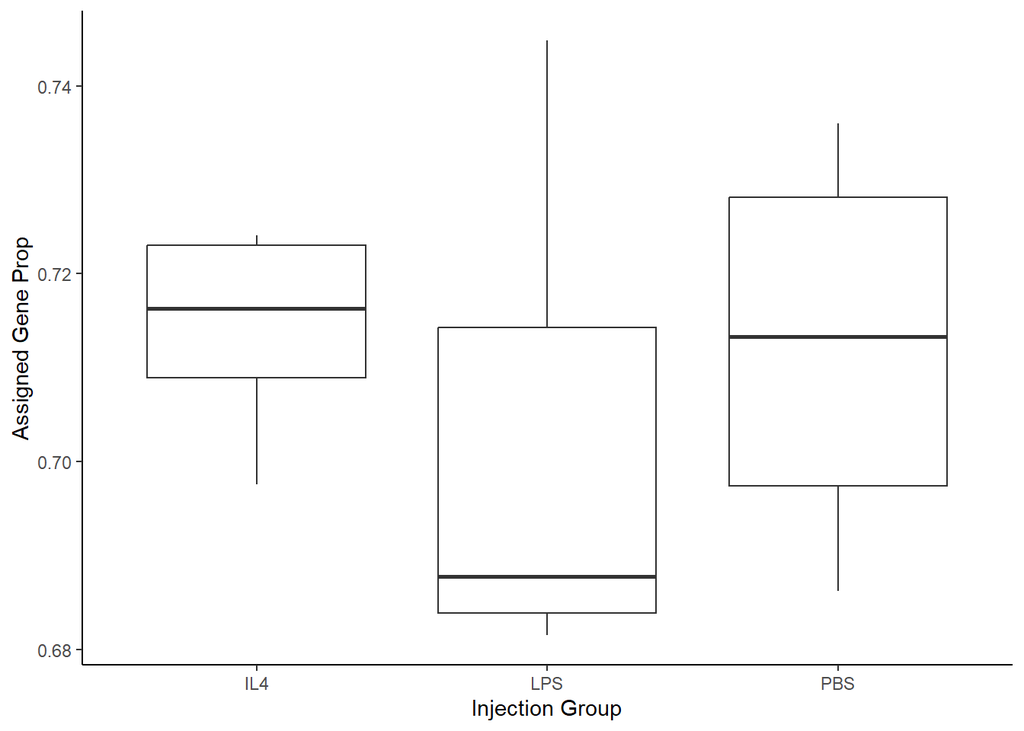

```r
# Plot gene expression according to the injection group
ggplot(as.data.frame(colData(rse_gene_SRP194918)),
       aes(y = assigned_gene_prop,
           x = sra_attribute.injected_with)) +
  geom_boxplot() +
  ylab("Assigned Gene Prop") +
  xlab("Injection Group") +
  theme_classic()
```

```r
# Create the model matrix according to the injection group
mod <- model.matrix(~ sra_attribute.injected_with + assigned_gene_prop,
                    data = colData(rse_gene_SRP194918)
)
colnames(mod)
```

```
## [1] "(Intercept)"                    "sra_attribute.injected_withLPS"
## [3] "sra_attribute.injected_withPBS" "assigned_gene_prop"
```

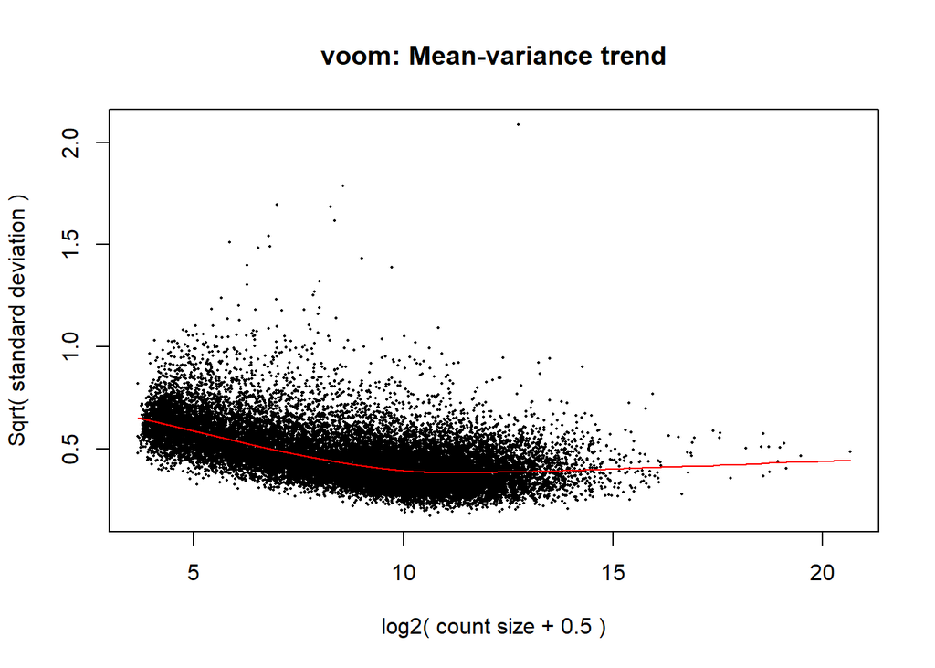

```r
# Estimate the mean-variance relationship
vGene <- voom(dge, mod, plot = TRUE)
```

```r
# Compute statistics by Bayes method
eb_results <- eBayes(lmFit(vGene))

# Extract the top genes
de_results <- topTable(
  eb_results,
  coef = c(2, 3),
  number = nrow(rse_gene_SRP194918),
  sort.by = "none"
)

# Calculate the number of significant genes
table(de_results$adj.P.Val < 0.05)
```

```
##
## FALSE  TRUE
## 21829   274
```

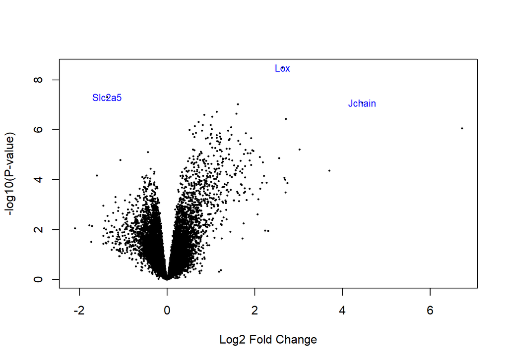

```r
# Plot the differentially expresed genes when injected with LPS
volcanoplot(eb_results, coef = 2, highlight = 3, names = de_results$gene_name)
```

```r
# Review the top genes information
de_results[de_results$gene_name %in% c("Jchain", "Lox", "Slc2a5"), ]
```

```
##                       source type bp_length phase               gene_id
## ENSMUSG00000024529.14 HAVANA gene      4778    NA ENSMUSG00000024529.14
## ENSMUSG00000028976.10 HAVANA gene      3402    NA ENSMUSG00000028976.10
## ENSMUSG00000067149.6  HAVANA gene      2517    NA  ENSMUSG00000067149.6
##                            gene_type gene_name level      mgi_id
## ENSMUSG00000024529.14 protein_coding       Lox     2   MGI:96817
## ENSMUSG00000028976.10 protein_coding    Slc2a5     2 MGI:1928369
## ENSMUSG00000067149.6  protein_coding    Jchain     2   MGI:96493
##                                havana_gene  tag sra_attribute.injected_withLPS
## ENSMUSG00000024529.14 OTTMUSG00000073373.1 <NA>                       2.632772
## ENSMUSG00000028976.10 OTTMUSG00000010389.2 <NA>                      -1.372050
## ENSMUSG00000067149.6  OTTMUSG00000036864.2 <NA>                       4.452633
##                       sra_attribute.injected_withPBS   AveExpr        F
## ENSMUSG00000024529.14                     0.66166712 0.4088484 63.29376
## ENSMUSG00000028976.10                    -0.09109408 1.1191055 46.69235
## ENSMUSG00000067149.6                      1.51578719 2.0405254 40.01448
##                            P.Value    adj.P.Val
## ENSMUSG00000024529.14 1.330165e-08 0.0002940064
## ENSMUSG00000028976.10 1.243272e-07 0.0013740021
## ENSMUSG00000067149.6  3.720316e-07 0.0020557536
```

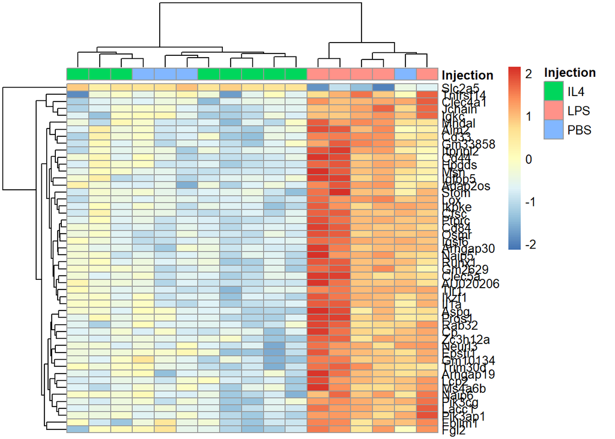

```r
# Heatmap of the 50 top genes
exprs_heatmap <- vGene$E[rank(de_results$adj.P.Val) <= 50, ]

# Create a dataframe with the injection group
df <- as.data.frame(colData(rse_gene_SRP194918)$sra_attribute.injected_with)

# Rename the columns and rows
colnames(df) <- c("Injection")
rownames(df) <- colnames(exprs_heatmap)

# Change the gene ID for the gene name
row.names(exprs_heatmap) <-
  de_results$gene_name[rank(de_results$adj.P.Val) <= 50]

# Create the heatmap
pheatmap(
  exprs_heatmap,
  cluster_rows = TRUE,
  cluster_cols = TRUE,
  show_colnames = FALSE,
  annotation_col = df,
  scale = "row",
)
```

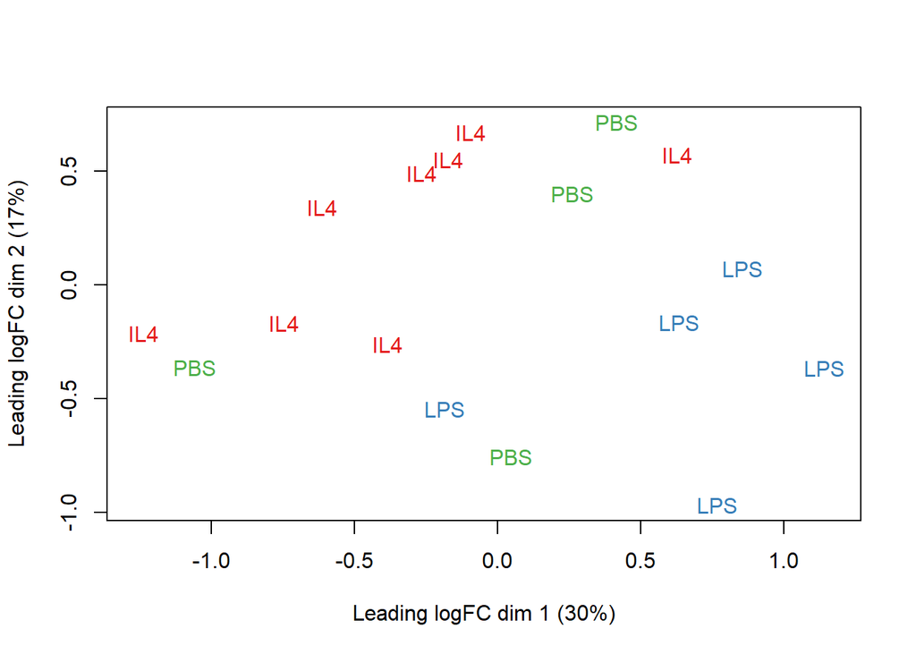

```r
# MDS plot according to the injection group
col.group <- df$Injection
levels(col.group) <- brewer.pal(nlevels(col.group), "Set1")
col.group <- as.character(col.group)
plotMDS(vGene$E, labels = df$Injection, col = col.group)
```

# 7 Biological discussion and conclusions

The differential expression analysis showed that the group injected with LPS was slightly more affected than the group injected with PBS. This is because LPS is a potent activator of microglia, and it is known that activated microglia can promote α-syn aggregation. It is imortant to mention that model was built using coefficients 2 and 3, because those were the columns indicating injections with either PBS or LPS (if none of them, that means that the sample was injected with IL-4) Also, the 3 top genes that were most differentially expressed in the group injected with LPS were Jchain, Lox, and Slc2a5. These genes are related to the immune response, oxidative stress, and glucose transport, respectively; and they are also involved in inflammation, which is a process that is usually present in PD.

# References

George, Sonia, Nolwen L. Rey, Trevor Tyson, Corinne Esquibel, Lindsay Meyerdirk, Emily Schulz, Steven Pierce, et al. 2019. “Microglia Affect α-Synuclein Cell-to-Cell Transfer in a Mouse Model of Parkinson’s Disease.” *Molecular Neurodegeneration* 14 (August). https://doi.org/10.1186/s13024-019-0335-3.

Poewe, Werner, Klaus Seppi, Caroline M. Tanner, Glenda M. Halliday, Patrik Brundin, Jens Volkmann, Anette Eleonore Schrag, and Anthony E. Lang. 2017. “Parkinson Disease.” *Nature Reviews Disease Primers 2017 3:1* 3 (March): 1–21. https://doi.org/10.1038/nrdp.2017.13.